# Tidyquant Demo

Matt Dancho

September 19, 2017

# tidyquant: What’s It Used For?

1. Getting web data from Yahoo! Finance, FRED Database, Quandl and more
2. Tidy application of financial and time series functions from `xts`, `zoo`, `quantmod`, `TTR` and `PerformanceAnalytics`
3. Graphing - Beautiful themes and financial geoms (e.g. `geom_ma`)
4. Working with portfolios
5. Financial performance analysis and portfolio attribution metrics
6. Great base for financial and time series analysis - Loads `tidyverse` and time series / financial packages behind the scenes making it a great starting point for any analysis

We’ll go over first two in this tutorial. See documentation for other topics.

# Load Libraries

```r
# devtools::install_github("business-science/tidyquant")
library(tidyquant) # Loads tidyverse, financial pkgs, used to get and manipulate data
```

# Getting data: tq_get

Use `tq_get()` to get data from the web. There’s a bunch of API’s it connects to including Yahoo! Finance, FRED Economic Database, Quandl, and more!

### Getting Stock Prices (Yahoo! Finance)

Pass a vector of stock prices to `tq_get()`.

```r
# Stock Prices from Yahoo! Finance
FANG_symbols <- c("FB", "AMZN", "NFLX", "GOOG")

FANG_data_d <- FANG_symbols %>%
    tq_get(get = "stock.prices", from = "2014-01-01", to = "2016-12-31")

FANG_data_d
```

```
## # A tibble: 3,024 x 8
##    symbol       date  open  high   low close   volume adjusted
##     <chr>     <date> <dbl> <dbl> <dbl> <dbl>    <dbl>    <dbl>
##  1     FB 2014-01-02 54.83 55.22 54.19 54.71 43195500    54.71
##  2     FB 2014-01-03 55.02 55.65 54.53 54.56 38246200    54.56
##  3     FB 2014-01-06 54.42 57.26 54.05 57.20 68852600    57.20
##  4     FB 2014-01-07 57.70 58.55 57.22 57.92 77207400    57.92
##  5     FB 2014-01-08 57.60 58.41 57.23 58.23 56682400    58.23
##  6     FB 2014-01-09 58.65 58.96 56.65 57.22 92253300    57.22
##  7     FB 2014-01-10 57.13 58.30 57.06 57.94 42449500    57.94
##  8     FB 2014-01-13 57.91 58.25 55.38 55.91 63010900    55.91
##  9     FB 2014-01-14 56.46 57.78 56.10 57.74 37503600    57.74
## 10     FB 2014-01-15 57.98 58.57 57.27 57.60 33663400    57.60
## # ... with 3,014 more rows
```

### Getting Economic Data (FRED)

This example comes from **Deputy Chief Economist at Freddie Mac, Leonard Kieffer’s** recent article [A (TIDYQUANT)UM OF SOLACE](http://lenkiefer.com/2017/09/18/a-tidyquant-um-of-solace/)

Pass a vector of FRED symbols to `tq_get()`.

```r
# Economic Data from the FRED
FRED_symbols <- c('ETOTALUSQ176N',    # All housing units
                  'EVACANTUSQ176N',   # Vacant
                  'EYRVACUSQ176N',    # Year-round vacant
                  'ERENTUSQ176N'      # Vacant for rent
)

FRED_data_m <- FRED_symbols %>%
    tq_get(get="economic.data", from = "2001-04-01")

FRED_data_m
```

```
## # A tibble: 260 x 3
##           symbol       date  price
##            <chr>     <date>  <int>
##  1 ETOTALUSQ176N 2001-04-01 117786
##  2 ETOTALUSQ176N 2001-07-01 118216
##  3 ETOTALUSQ176N 2001-10-01 118635
##  4 ETOTALUSQ176N 2002-01-01 119061
##  5 ETOTALUSQ176N 2002-04-01 119483
##  6 ETOTALUSQ176N 2002-07-01 119909
##  7 ETOTALUSQ176N 2002-10-01 120350
##  8 ETOTALUSQ176N 2003-01-01 120792
##  9 ETOTALUSQ176N 2003-04-01 121233
## 10 ETOTALUSQ176N 2003-07-01 121682
## # ... with 250 more rows
```

# Mutating Data: tq_transmute and tq_mutate

For applying `xts`, `zoo`, and `quantmod` functions in a “tidy” way. See below for Available Functions.

### tq_transmute

Returns a new data frame. Useful when **periodicity changes** the number of rows in the data.

```r
# Change periodicity from daily to monthly using to.period from xts
FANG_data_m <- FANG_data_d %>%
    group_by(symbol) %>%
    tq_transmute(
        select      = adjusted,
        mutate_fun  = to.period,
        period      = "months"
    )

FANG_data_m
```

```
## # A tibble: 144 x 3
## # Groups:   symbol [4]
##    symbol       date adjusted
##     <chr>     <date>    <dbl>
##  1     FB 2014-01-31    62.57
##  2     FB 2014-02-28    68.46
##  3     FB 2014-03-31    60.24
##  4     FB 2014-04-30    59.78
##  5     FB 2014-05-30    63.30
##  6     FB 2014-06-30    67.29
##  7     FB 2014-07-31    72.65
##  8     FB 2014-08-29    74.82
##  9     FB 2014-09-30    79.04
## 10     FB 2014-10-31    74.99
## # ... with 134 more rows
```

Before transformation - Too much data.

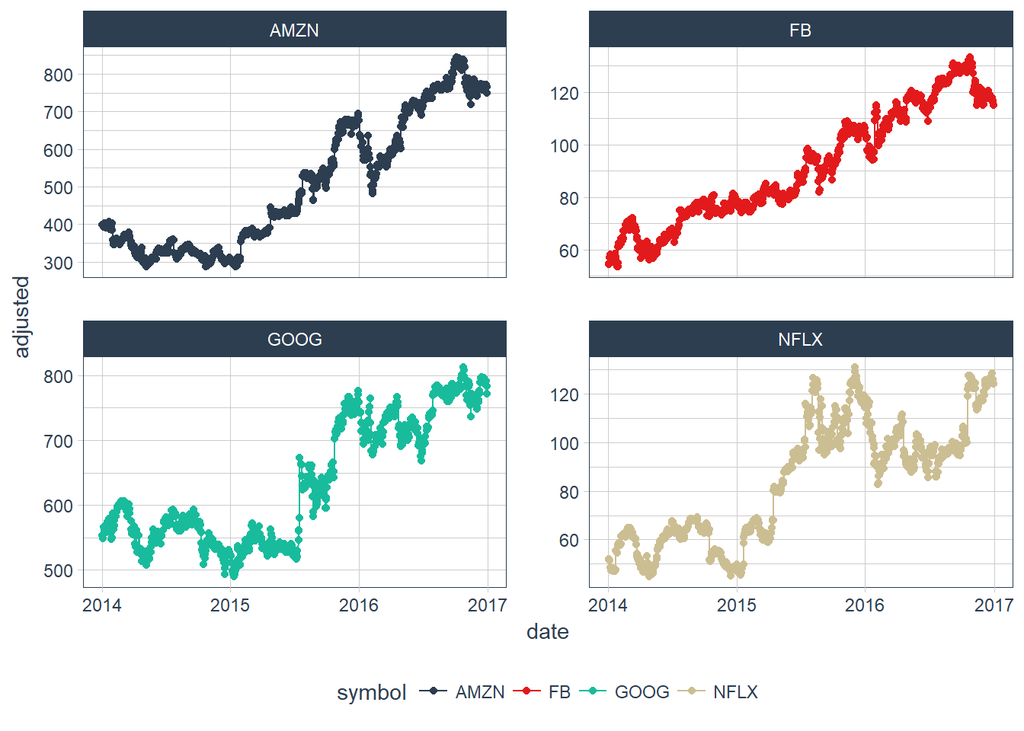

```r
# Daily data
FANG_data_d %>%
    ggplot(aes(date, adjusted, color = symbol)) +
    geom_point() +
    geom_line() +
    facet_wrap(~ symbol, ncol = 2, scales = "free_y") +
    scale_color_tq() +
    theme_tq()
```

After transformation - Easy to understand.

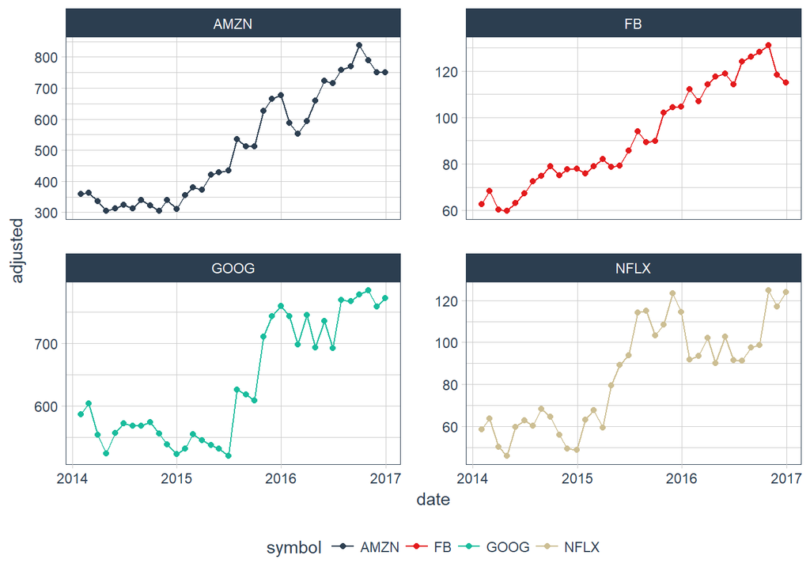

```r
# Monthly data
FANG_data_m %>%
    ggplot(aes(date, adjusted, color = symbol)) +
    geom_point() +
    geom_line() +
    facet_wrap(~ symbol, ncol = 2, scales = "free_y") +
    scale_color_tq() +
    theme_tq()
```

### tq_mutate

Returns the original data plus the mutated data.

```r
# Lags - Get first 5 lags
column_names <- paste0("lag", 1:5)

FANG_data_d %>%
    select(symbol, date, adjusted) %>%
    group_by(symbol) %>%
    tq_mutate(
        select     = adjusted,
        mutate_fun = lag.xts,
        k          = 1:5,
        col_rename = column_names
    )
```

```
## # A tibble: 3,024 x 8
## # Groups:   symbol [4]
##    symbol       date adjusted  lag1  lag2  lag3  lag4  lag5
##     <chr>     <date>    <dbl> <dbl> <dbl> <dbl> <dbl> <dbl>
##  1     FB 2014-01-02    54.71    NA    NA    NA    NA    NA
##  2     FB 2014-01-03    54.56 54.71    NA    NA    NA    NA
##  3     FB 2014-01-06    57.20 54.56 54.71    NA    NA    NA
##  4     FB 2014-01-07    57.92 57.20 54.56 54.71    NA    NA
##  5     FB 2014-01-08    58.23 57.92 57.20 54.56 54.71    NA
##  6     FB 2014-01-09    57.22 58.23 57.92 57.20 54.56 54.71
##  7     FB 2014-01-10    57.94 57.22 58.23 57.92 57.20 54.56
##  8     FB 2014-01-13    55.91 57.94 57.22 58.23 57.92 57.20
##  9     FB 2014-01-14    57.74 55.91 57.94 57.22 58.23 57.92
## 10     FB 2014-01-15    57.60 57.74 55.91 57.94 57.22 58.23
## # ... with 3,014 more rows
```

### Available Functions

A bunch of functions that can be used!

```r
# Available functions
# mutate_fun =
tq_transmute_fun_options()
```

```
## $zoo
##  [1] "rollapply"          "rollapplyr"         "rollmax"
##  [4] "rollmax.default"    "rollmaxr"           "rollmean"
##  [7] "rollmean.default"   "rollmeanr"          "rollmedian"
## [10] "rollmedian.default" "rollmedianr"        "rollsum"
## [13] "rollsum.default"    "rollsumr"
##
## $xts
##  [1] "apply.daily"     "apply.monthly"   "apply.quarterly"
##  [4] "apply.weekly"    "apply.yearly"    "diff.xts"
##  [7] "lag.xts"         "period.apply"    "period.max"
## [10] "period.min"      "period.prod"     "period.sum"
## [13] "periodicity"     "to.daily"        "to.hourly"
## [16] "to.minutes"      "to.minutes10"    "to.minutes15"
## [19] "to.minutes3"     "to.minutes30"    "to.minutes5"
```

[output cut: 42 more lines]

# More Information

- Check out our [GitHub Page](https://github.com/business-science/tidyquant)
- Check out our [tidyquant documentation](https://business-science.github.io/tidyquant/)
- Check out our [Business Science Insights Blog](http://www.business-science.io/blog/index.html)